# Components

The `Components` module defines the abstract interfaces and concrete types used by `SpreadModels` to represent wind, moisture, terrain, burnout, burn-in, and directional spread. Each component is a callable struct with signature `(t, x, y)` that returns the relevant physical quantity at a given time and location.

## Abstract Interfaces

Every component category has an abstract supertype. Custom components subtype these and implement the callable interface.

| Abstract Type | Signature | Returns |
| --- | --- | --- |
| `AbstractWind` | `wind(t, x, y)` | `(speed, direction)` — speed [km/h], direction FROM [rad] |
| `AbstractMoisture` | `moisture(t, x, y)` | `FuelClasses` — moisture fractions per size class |
| `AbstractTerrain` | `terrain(t, x, y)` | `(slope, aspect)` — slope [fraction], aspect [rad] |
| `AbstractBurnout` | `burnout(t_burning)` | `Float64 ∈ [0, 1]` — spread intensity decay |
| `AbstractBurnin` | `burnin(t_burning)` | `Float64 ∈ [0, 1]` — spread intensity ramp-up |
| `AbstractBlendingMode` | *(used internally by `RothermelModel`)* | Directional interpolation of spread rate |
| `AbstractSpotting` | `spot!(grid, model, dt)` | Ignites new spot fires from lofted embers |
| `AbstractSuppression` | `suppress!(grid, model, dt)` | Modifies grid to reflect suppression actions |

**Note**

`AbstractSpotting` and `AbstractSuppression` are defined but not yet connected to `simulate!`. They are reserved for future use.

## Wind

```julia
UniformWind{T}(; speed, direction=0.0)
```

Spatially and temporally constant wind field.

#### Fields

- `speed::T` - Midflame wind speed [km/h]
- `direction::T` - Direction wind blows FROM [radians]

```julia
wind = UniformWind(speed=8.0, direction=π/4)
wind(0.0, 0.0, 0.0)  # (speed, direction)
```

```
(8.0, 0.7853981633974483)
```

To create a spatially varying wind field, subtype `AbstractWind`:

```julia
struct GradientWind <: AbstractWind
    base_speed::Float64
    gradient::Float64    # speed increase per meter in x
    direction::Float64
end

function (w::GradientWind)(t, x, y)
    speed = w.base_speed + w.gradient * x
    (speed, w.direction)
end
```

## Moisture

```julia
UniformMoisture{T}(moisture::FuelClasses{T})
```

Spatially and temporally constant fuel moisture.

```julia
M = FuelClasses(d1=0.06, d10=0.07, d100=0.08, herb=0.0, wood=0.0)
moist = UniformMoisture(M)
moist(0.0, 0.0, 0.0)
```

```
FuelClasses{Float64}(d1=0.06, d10=0.07, d100=0.08, herb=0.0, wood=0.0)
```

### Dynamic Moisture

```julia
DynamicMoisture(grid::LevelSetGrid, moisture::FuelClasses; dry_rate=0.1, recovery_rate=0.001, min_d1=0.03)
```

Spatially varying fuel moisture that responds to fire-induced drying.

The 1-hr dead fuel moisture (`d1`) varies spatially while other size classes remain constant. As the fire front approaches, radiative heat flux dries unburned fuel ahead of the front. Moisture also recovers toward the ambient value over time.

The drying model at each unburned cell:

```julia
dM/dt = -dry_rate / (φ² + 1) + recovery_rate · (M_ambient - M)
```

where `φ` is the level set value (approximate distance to the fire front in meters). Moisture is clamped to `[min_d1, ambient_d1]` to prevent unrealistic drying.

#### Fields

- `d1::M` - Spatially varying 1-hr dead fuel moisture (`M <: AbstractMatrix{T}`) [fraction]
- `base::FuelClasses{T}` - Moisture values for other size classes
- `ambient_d1::T` - Equilibrium d1 moisture from weather [fraction]
- `dry_rate::T` - Fire-induced drying coefficient [fraction/min]
- `recovery_rate::T` - Moisture recovery rate toward ambient [1/min]
- `min_d1::T` - Minimum d1 moisture floor [fraction]
- `dx::T`, `dy::T`, `x0::T`, `y0::T` - Grid geometry for coordinate lookup

```julia
grid = LevelSetGrid(100, 100, dx=30.0)
ignite!(grid, 1500.0, 1500.0, 200.0)
M = FuelClasses(d1=0.06, d10=0.07, d100=0.08, herb=0.0, wood=0.0)
dm = DynamicMoisture(grid, M, dry_rate=0.1, recovery_rate=0.001)
dm(0.0, 1500.0, 1500.0)  # moisture at ignition point
```

```
FuelClasses{Float64}(d1=0.06, d10=0.07, d100=0.08, herb=0.0, wood=0.0)
```

## Terrain

```julia
FlatTerrain()
```

Flat terrain (zero slope everywhere).

```julia
FlatTerrain()(0.0, 0.0, 0.0)  # (slope, aspect)
```

```
(0.0, 0.0)
```

```julia
UniformSlope{T}(; slope, aspect=0.0)
```

Spatially constant terrain slope.

#### Fields

- `slope::T` - Terrain slope as rise/run [fraction]
- `aspect::T` - Downslope direction [radians]

```julia
slope = UniformSlope(slope=0.3, aspect=0.0)
slope(0.0, 0.0, 0.0)
```

```
(0.3, 0.0)
```

## Burnout

Burnout models scale the spread rate of already-burning cells to simulate fuel exhaustion.

| Type | Behavior |
| --- | --- |
| `NoBurnout()` | No decay — fire spreads at full intensity indefinitely |
| `ExponentialBurnout(τ)` | Intensity decays as `exp(-t/τ)` |
| `LinearBurnout(τ)` | Intensity decreases linearly to zero over `τ` minutes |

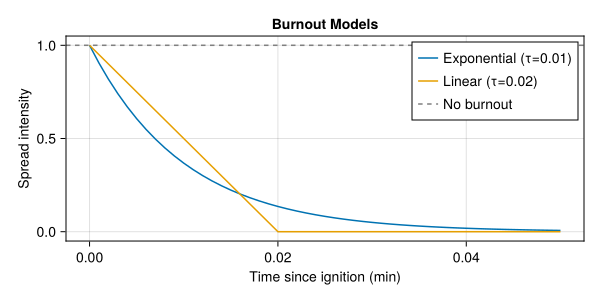

```julia
t = 0:0.001:0.05
bo_exp = ExponentialBurnout(0.01)
bo_lin = LinearBurnout(0.02)

fig = Figure(size=(600, 300))
ax = Axis(fig[1, 1], xlabel="Time since ignition (min)", ylabel="Spread intensity",
    title="Burnout Models")
lines!(ax, collect(t), bo_exp.(t), label="Exponential (τ=0.01)")
lines!(ax, collect(t), bo_lin.(t), label="Linear (τ=0.02)")
hlines!(ax, [1.0], color=:gray, linestyle=:dash, label="No burnout")
axislegend(ax, position=:rt)
fig
```

## Burn-in

Burn-in models ramp up spread intensity after ignition, preventing freshly ignited cells from immediately propagating fire in all directions.

| Type | Behavior |
| --- | --- |
| `NoBurnin()` | Full intensity immediately upon ignition |
| `ExponentialBurnin(τ)` | Ramps as `1 - exp(-t/τ)` |
| `LinearBurnin(τ)` | Linear ramp from `0` to `1` over `τ` minutes |

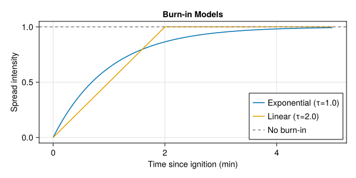

```julia
t = 0:0.01:5.0
bi_exp = ExponentialBurnin(1.0)
bi_lin = LinearBurnin(2.0)

fig = Figure(size=(600, 300))
ax = Axis(fig[1, 1], xlabel="Time since ignition (min)", ylabel="Spread intensity",
    title="Burn-in Models")
lines!(ax, collect(t), bi_exp.(t), label="Exponential (τ=1.0)")
lines!(ax, collect(t), bi_lin.(t), label="Linear (τ=2.0)")
hlines!(ax, [1.0], color=:gray, linestyle=:dash, label="No burn-in")
axislegend(ax, position=:rb)
fig
```

## Directional Spread (Blending Modes)

Blending modes (`AbstractBlendingMode`) control how the spread rate is interpolated across angles relative to the push direction (combined wind + slope vector). Given the head-fire rate `R_head` (maximum, aligned with push) and a base rate `R_base` (no wind/slope), the blending mode computes the effective spread rate at any angle `θ` from the push direction.

```julia
CosineBlending()
```

Cosine-based directional spread model (default).

The spread rate at angle `θ` from the push direction is:

```julia
R(θ) = R_base + (R_head - R_base) · max(0, cos θ)
```

```julia
EllipticalBlending(; formula=:anderson)
```

Elliptical fire spread model based on Anderson (1983).

The normal speed at angle `θ` from the push direction is:

```julia
F_n(θ) = R_head/(1+ε) · (√(cos²θ + sin²θ/LB²) + ε·cos θ)
```

where `ε` is the fire eccentricity and `LB` the length-to-breadth ratio, both derived from the effective midflame wind speed. The first term is the ellipse expansion and the second is the drift that places the ignition at the rear focus (as in the Anderson/Richards fire ellipse convention).

#### Fields

- `formula::Symbol` - Length-to-breadth formula: `:anderson` (default) or `:green`

### Examples

```julia
model = RothermelModel(
    SHORT_GRASS,
    UniformWind(speed=8.0),
    UniformMoisture(FuelClasses(d1=0.06, d10=0.07, d100=0.08, herb=0.0, wood=0.0)),
    FlatTerrain(),
    EllipticalBlending(),
)
```

### Comparison

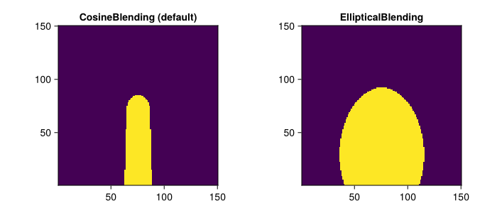

```julia
M = FuelClasses(d1=0.06, d10=0.07, d100=0.08, herb=0.0, wood=0.0)

g_cos = LevelSetGrid(150, 150, dx=30.0)
ignite!(g_cos, 2250.0, 2250.0, 200.0)
m_cos = RothermelModel(SHORT_GRASS, UniformWind(speed=10.0), UniformMoisture(M), FlatTerrain())
simulate!(g_cos, m_cos, steps=200)

g_ell = LevelSetGrid(150, 150, dx=30.0)
ignite!(g_ell, 2250.0, 2250.0, 200.0)
m_ell = RothermelModel(SHORT_GRASS, UniformWind(speed=10.0), UniformMoisture(M), FlatTerrain(), EllipticalBlending())
simulate!(g_ell, m_ell, steps=200)

fig = Figure(size=(700, 300))
ax1 = Axis(fig[1, 1], title="CosineBlending (default)", aspect=DataAspect())
ax2 = Axis(fig[1, 2], title="EllipticalBlending", aspect=DataAspect())
heatmap!(ax1, burned(g_cos))
heatmap!(ax2, burned(g_ell))
fig
```

### Length-to-Breadth Ratio

```julia
length_to_breadth(U; formula=:anderson)
```

Compute the fire length-to-breadth ratio from effective midflame wind speed `U` [m/s].

#### Formulas

- `:anderson` (default) — Anderson (1983): `LB = 0.936 · exp(0.2566 · U) + 0.461 · exp(-0.1548 · U) - 0.397`
- `:green` — Green (1983): `LB = 1.1 · U^0.464` (suitable for grass)

Returns at least `1.0` (a circle at zero wind).

### Examples

```julia
length_to_breadth(0.0)   # ≈ 1.0 (circle)
length_to_breadth(2.0)   # > 1.0 (elongated)
```

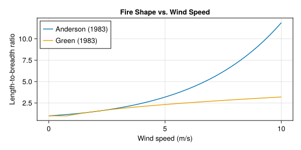

```julia
U = 0:0.1:10.0

fig = Figure(size=(600, 300))
ax = Axis(fig[1, 1], xlabel="Wind speed (m/s)", ylabel="Length-to-breadth ratio",
    title="Fire Shape vs. Wind Speed")
lines!(ax, collect(U), length_to_breadth.(U, formula=:anderson), label="Anderson (1983)")
lines!(ax, collect(U), length_to_breadth.(U, formula=:green), label="Green (1983)")
axislegend(ax, position=:lt)
fig
```

## Custom Components

All components follow the same pattern: subtype the abstract type and implement the callable interface.

```julia
struct MyWindField <: AbstractWind
    data::Matrix{Float64}
    dx::Float64
    dy::Float64
end

function (w::MyWindField)(t, x, y)
    # Look up wind from gridded data
    i = clamp(round(Int, y / w.dy), 1, size(w.data, 1))
    j = clamp(round(Int, x / w.dx), 1, size(w.data, 2))
    speed = w.data[i, j]
    direction = 0.0  # always from north
    (speed, direction)
end
```

For dynamic components that evolve with the fire, implement `update!`:

```julia
function SpreadModels.update!(w::MyWindField, grid::LevelSetGrid, dt)
    # Update wind field based on fire state
end
```